# PCA and WCGNA

This notebook continues on from ’Mtb_modules_notebook.Rmd", using the counts matrix generated from applying Baerhunter’s predicted ncRNAs to multiple Mtb RNAseq datasets. It involves count normalisation, transformation, batch correction, PCA and WGCNA analysis.

1. Create counts matrix and DESeq object

Create deseq dataset from counts matrix (can use variety of objects including ranged summarised experiments, etc.). Must include formula for design of experiment. “By default, the functions in this package will use the last variable in the formula for building results tables and plotting. ~ 1 can be used for no design, although users need to remember to switch to another design for differential testing.”

so I don’t really have to indicate a ‘control’ for this experiment since I’m not really going to be looking at differential expression.

```r
# read in counts matrix and create deseq dataset

countdata<-read.csv("count_matrix_complete.csv")
head(countdata)
```

|  | ERR2103718 | ERR2103722 | ERR2103723 | SRR3725585 | SRR3725586 | SRR3725587 | SRR3725588 | SRR3725589 | SRR3725590 | SRR3725591 | SRR3725592 | SRR3725593 | SRR3725594 | SRR3725595 | SRR3725596 | SRR3725597 | SRR3725598 | SRR3725599 | SRR1917694 | SRR1917695 | SRR1917696 | SRR1917697 | SRR1917698 | SRR1917699 | SRR1917700 | SRR1917701 | SRR1917702 | SRR1917703 | SRR1917704 | … |
| --- | --- | --- | --- | --- | --- | --- | --- | --- | --- | --- | --- | --- | --- | --- | --- | --- | --- | --- | --- | --- | --- | --- | --- | --- | --- | --- | --- | --- | --- | --- |
| 1 | 2485 | 3479 | 2775 | 3396 | 3286 | 3058 | 5063 | 4560 | 5212 | 5425 | 3987 | 5259 | 5740 | 6719 | 6818 | 6076 | 6627 | 8501 | 2065 | 1014 | 2466 | 9823 | 8661 | 5945 | 12336 | 7003 | 3645 | 14867 | 11149 | … |
| 2 | 686 | 744 | 574 | 105 | 112 | 105 | 1038 | 875 | 1045 | 1082 | 793 | 1008 | 923 | 1220 | 1112 | 855 | 1017 | 1029 | 809 | 297 | 532 | 2044 | 2179 | 1547 | 3042 | 1631 | 1026 | 3987 | 2817 | … |
| 3 | 403 | 531 | 358 | 131 | 128 | 127 | 1368 | 1316 | 1432 | 1053 | 836 | 987 | 936 | 1032 | 887 | 791 | 848 | 1035 | 126 | 63 | 124 | 368 | 539 | 406 | 557 | 283 | 191 | 938 | 772 | … |
| 4 | 192 | 236 | 160 | 143 | 171 | 135 | 965 | 880 | 1061 | 813 | 611 | 714 | 607 | 713 | 656 | 478 | 560 | 613 | 289 | 81 | 223 | 869 | 1170 | 827 | 1231 | 651 | 436 | 1490 | 1053 | … |
| 5 | 2956 | 4774 | 3276 | 23857 | 24102 | 22445 | 25160 | 23105 | 28173 | 23020 | 17086 | 21755 | 21355 | 24146 | 22409 | 19303 | 23059 | 28678 | 6818 | 3056 | 6380 | 18951 | 25490 | 18981 | 23826 | 11500 | 7900 | 21658 | 17337 | … |
| 6 | 2930 | 3761 | 2623 | 13825 | 13415 | 12533 | 22227 | 20921 | 24726 | 21861 | 16494 | 20047 | 18733 | 21932 | 19357 | 16124 | 19317 | 22891 | 4710 | 1850 | 3839 | 15344 | 21687 | 16353 | 19569 | 9646 | 6515 | 20198 | 16728 | … |

```r
#inspection of matrix
class(countdata)
```

```
[1] "data.frame"
```

```r
nrow(countdata)
```

```
[1] 6486
```

```r
length(countdata)
```

```
[1] 52
```

```r
# read in sample/dataset
datasets<-read.table("dataset_samples.txt", sep = " ", header=F)
colnames(datasets)<-c("sample", "study")

# read in conditions/sample
conditions<-read.csv("mtb_conditions.txt")
conditions$study<-datasets$study
View(conditions)

# create DeSeq dataset

#check order is same for count data and conditions data
all(conditions$sample_names == colnames(countdata))
```

```
[1] TRUE
```

```r
#construct deseq dataset
dds_raw<-DESeqDataSetFromMatrix(countData = countdata,
                              colData = conditions,
                              design = ~1)
nrow(dds_raw)
```

```
[1] 6486
```

```r
#6486
# pre-filter reads to exclude rows with very low expression--makes more efficient
keep <- rowSums(counts(dds_raw)) >= 10
dds_filter <- dds_raw[keep,]
nrow(dds_filter)
```

```
[1] 6483
```

```r
#6483
# this filters only 3 rows, so not really much point
dds_raw<-dds_filter
```

2. Normalisation  
   Sequencing depth normalisation probably quite important here since depth varies quite a bit between experiments.

```r
#sum of depth after normalization
colSums(counts(dds_raw, normalized=F))
```

```
ERR2103718 ERR2103722 ERR2103723 SRR3725585 SRR3725586 SRR3725587 SRR3725588
   4046070    4036758    3671372   11741414   11948611   10518491   11323699
SRR3725589 SRR3725590 SRR3725591 SRR3725592 SRR3725593 SRR3725594 SRR3725595
  10638870   11972041   12537795    9092412   11324662   10389903   12445802
SRR3725596 SRR3725597 SRR3725598 SRR3725599 SRR1917694 SRR1917695 SRR1917696
  11810320    9854175   11361139   13069122    6401106    3156785    5993382
SRR1917697 SRR1917698 SRR1917699 SRR1917700 SRR1917701 SRR1917702 SRR1917703
  12423195   16591850   12710956   21162086   11296441    7264005   19201331
SRR1917704 SRR1917705 SRR1917706 SRR1917707 SRR1917708 SRR1917709 SRR1917710
  14580314    5710327    1903412   11459068   14461420   14920939    7290683
SRR1917711 SRR1917712 SRR1917713 SRR1917714 SRR1917715 SRR5689224 SRR5689225
   9135168   14527511   25157925    3916499    3085368   23993844   23659833
SRR5689226 SRR5689227 SRR5689228 SRR5689229 SRR5689230 SRR5689231 SRR5689232
  19068008   25245981   29975856   15134749   28314961   20930716   21063446
SRR5689233 SRR5689234 SRR5689235
  17841412   27840157   26533860
```

> For genes with high counts, both the VST and the rlog will give similar result to the ordinary log2 transformation of normalized counts. For genes with lower counts, however, the values are shrunken towards a middle value. The VST or rlog-transformed data then become approximately homoskedastic (more flat trend in the meanSdPlot), and can be used directly for computing distances between samples, making PCA plots, or as input to downstream methods which perform best with homoskedastic data. In datasets with large variation in sequencing depth (dynamic range of size factors 4) we observed undesirable artifacts in the performance of the VST

> The rlog is less sensitive to size factors, which can be an issue when size factors vary widely. Should check these for my samples. Try with both rlog and vst.

> The more the size factors differ, the more residual dependence of the variance on the mean will be found in the transformed data. rlog is a transformation which can perform better in these cases. As shown in the vignette, the function meanSdPlot from the package vsn can be used to see whether this is a problem.

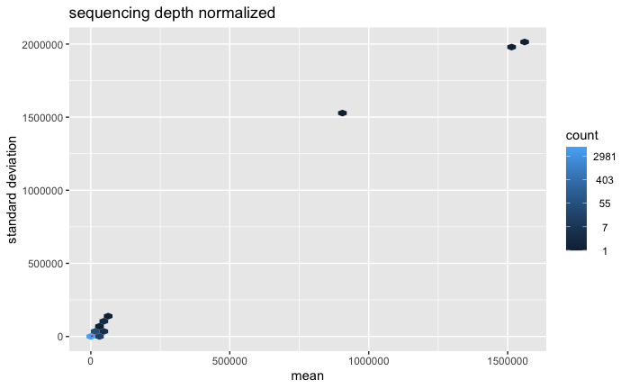

```r
library(vsn)
# When the expected amount of variance is approximately the same across different
# mean values, the data is said to be homoskedastic. For RNA-seq counts, however,
# the expected variance grows with the mean.
SdPlot <- meanSdPlot(counts_normalized, ranks = F, plot = F)
SdPlot$gg + ggtitle("sequencing depth normalized") + ylab("standard deviation")
```

```r
NA
NA
NA
NA
```

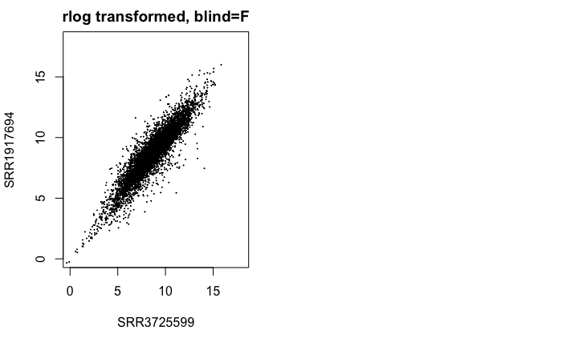

Don’t see any difference with blind T/F. There are no controls set, so shouldn’t really make a difference here. YenYi used blind=FALSE with VST.

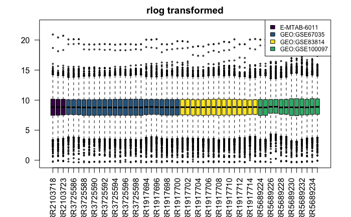

```r
par(mfrow=c(1,1))
rlog_boxplot <- boxplot(rlog_norm_se,
                        PchCex =0.01,
                        axes=TRUE,
                        las=2,
                        col=study_colors,
                        #ylim = c(0,4500),
                        outline =TRUE,
                        outcex=0.35,
                        main=c("rlog transformed"))
legend("topright", legend=c("E-MTAB-6011", "GEO:GSE67035", "GEO:GSE83814", "GEO:GSE100097"),
               col = c("#440154FF","#31688EFF","#FDE725FF","#35B779FF"),
               fill = c("#440154FF","#31688EFF","#FDE725FF","#35B779FF"),
               cex = 0.75,
               pt.cex = 1)
```

There are still a lot of low counts here.

VST transformation

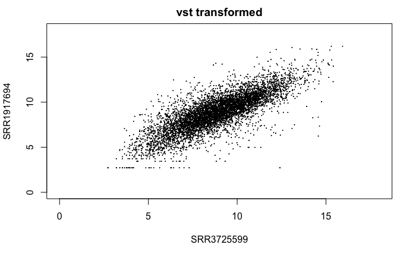

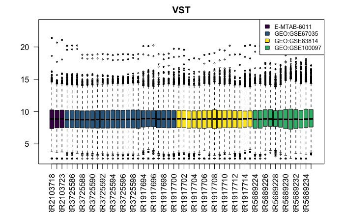

```r
plot(vst_norm_se[,18:19], cex=.1, main = "vst transformed", xlim=c(0,18), ylim=c(0,18))

vst_boxplot <- boxplot(vst_norm_se,
                        PchCex =0.01,
                        axes=TRUE,
                        las=2,
                        col=study_colors,
                        #ylim = c(0,4500),
                        outline =TRUE,
                        outcex=0.35,
                        main="VST")

legend("topright", legend=c("E-MTAB-6011", "GEO:GSE67035", "GEO:GSE83814", "GEO:GSE100097"),
               col = c("#440154FF","#31688EFF","#FDE725FF","#35B779FF"),
               fill = c("#440154FF","#31688EFF","#FDE725FF","#35B779FF"),
               cex = 0.75,
               pt.cex = 1)
```

A lot fewer low counts, but when I plot different studies against each other, lower correlation than with rlog. Perhaps this is because of different sequencing depths in the different studies.

4. PCA plots and hierarchical dendrograms: these will help us identify any batch effects.

> Related to the distance matrix is the PCA plot, which shows the samples in the 2D plane spanned by their first two principal components. This type of plot is useful for visualizing the overall effect of experimental covariates and batch effects.

There will be batch effects, we can try to eliminate using limma.

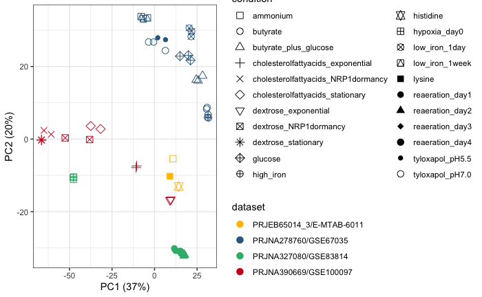

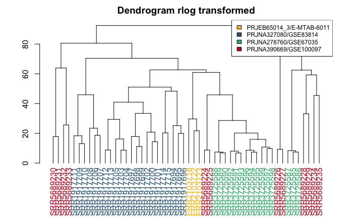

These show obvious batch effects, especially for studies GSE83814 and E-MTAB-6011.

5. Eliminate batch effects with limma

> The design matrix is used to describe comparisons between the samples, for example treatment effects, that should not be removed. The function (in effect) fits a linear model to the data, including both batches and regular treatments, then removes the component due to the batch effects.

> In most applications, only the first batch argument will be needed. This case covers the situation where the data has been collected in a series of separate batches.

```r
#batch effect correction using limma; requirement to define batch effect
library(limma)

batch.table <- data.frame(study=conditions$study,condition=conditions$condition)
#head(batch.table)

# uses log-expression values for series of samples, and needs design matrix
limma_rlog<-removeBatchEffect(x=rlog_norm_se,
                                      batch=batch.table$study,
                                      batch2=NULL,
                                      covariates=NULL,
                                      design=model.matrix(~batch.table$condition))
#Coefficients not estimable: batch1 batch2 batch3
#Partial NA coefficients for 6486 probe(s)

#Despite warning, is limma still correcting for purposes of visualisation for use with pca, etc?

# make PCA plot for limma batch corrected

#generating PCA table
PCA.data <- data.frame(row.names=colnames(countdata),
                               condition=factor(conditions$condition),
                               dataset=factor(conditions$study))

PCA.data.plot <- prcomp(t(limma_rlog))
pca_rlog_limma_df <- as.data.frame(PCA.data.plot$x)
pca_rlog_limma_df$condition<-PCA.data$condition
pca_rlog_limma_df$dataset <-PCA.data$dataset
summary(PCA.data.plot)

#PCA plot for rlog transformed data
limma_plot <- ggplot(pca_rlog_limma_df,aes(x=PC1,y=PC2,color=dataset,shape=condition)) + scale_shape_manual(values = 0:21) + geom_point(size=3) + xlab("PC1 (32%)") + ylab("PC2 (18%)")
limma_plot <- limma_plot + scale_color_manual(values = toned_down_pal) + theme_bw()
limma_plot
## does not look corrected at all--identical plot to pre-limma?
# check dendrogram
```

[output not shown]

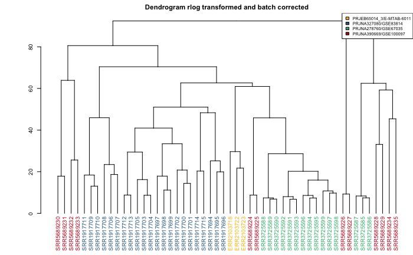

```r
# make hierarchical dendrogram to compare with pre-limma
#dendrogram for rlog transformed data with batch correction
sizeGrWindow(12,9)
par(cex=0.6)
par(mar=c(5,6,2,0))

group <-as.factor(conditions$study)
n_group <- length(unique(group))
cols <- toned_down_pal    #(n_group)
col_group <- cols[group]
hc <- hclust(dist(t(limma_rlog)),method="average")
dend <- as.dendrogram(hc)
col_group <- col_group[order.dendrogram(dend)]
limma_rlog_dend <- dend %>%
            set("labels_colors", col_group) %>% #change label colors to group
            plot(main = "Dendrogram rlog transformed and batch corrected")
legend("topright",
       legend = unique(group),
       fill = cols,
       cex = 0.75,
       pt.cex = 1)
```

```r
# Exactly the same--no batch correction at all. Need to include some control data in the design? Maybe all exponential cultures?
```

I got this same message when doing limma on VST data. I suspect it has more to do with lack of controls in design matrix.

Can I use day 3 and 4 from study GEO# GSE83814? These look like exponential growth. Can I use day 2?

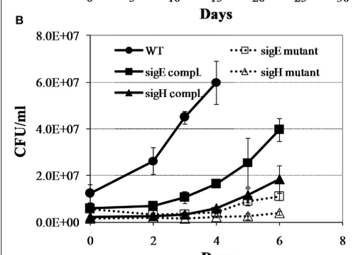

growth GEO:GSE83814

So for controls: reaeration days 3-4, tyloxapol_pH7.0, dextrose exponential

Create new dseq matrix with control design. Start with new dataframe of conditions.

```r
class(control_conditions.df)
```

```
[1] "data.frame"
```

Create new deseq dataset with design matrix using controls

# create DeSeq dataset

```r
nrow(dds_filter)
```

```
[1] 6483
```

Do rlog transformation blind T/F to see if control effects

```r
# use raw count data, not normalised for sequencing depth

# rlog transformed blind=F
rlog_control<-rlog(dds_control, blind=F)
```

```
rlog() may take a long time with 50 or more samples,
vst() is a much faster transformation
```

```r
#create summarized experiment matrix (se=summarized experiment)
rlog_control_se <- assay(rlog_control)

# rlog blind=T
rlc_T<-rlog(dds_control)
```

```
rlog() may take a long time with 50 or more samples,
vst() is a much faster transformation
```

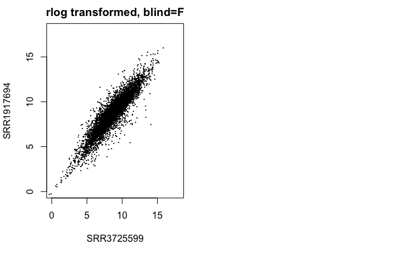

```r
rlc_T_control_se<-assay(rlc_T)

par(mfrow=c(1,2))
plot(rlog_norm_se[,18:19], cex=.1, main = "rlog transformed, blind=F", xlim=c(0,18), ylim=c(0,18))

plot(rlog_T_norm_se[,18:19], cex=.1, main = "rlog transformed, blind=TRUE", xlim=c(0,18), ylim=c(0,18))
```

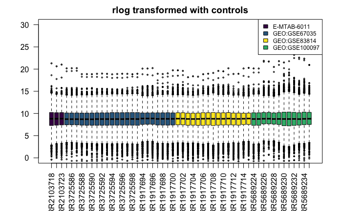

```r
par(mfrow=c(1,1))
rlc_boxplot <- boxplot(rlog_control_se,
                        PchCex =0.01,
                        axes=TRUE,
                        las=2,
                        col=study_colors,
                        ylim = c(0,30),
                        outline =TRUE,
                        outcex=0.35,
                        main=c("rlog transformed with controls"))
legend("topright", legend=c("E-MTAB-6011", "GEO:GSE67035", "GEO:GSE83814", "GEO:GSE100097"),
               col = c("#440154FF","#31688EFF","#FDE725FF","#35B779FF"),
               fill = c("#440154FF","#31688EFF","#FDE725FF","#35B779FF"),
               cex = 0.75,
               pt.cex = 1)
```

use limma to attempt to eliminate batch effects:

```r
# uses log-expression values for series of samples, and needs design matrix
limma_rlogc<-removeBatchEffect(x=rlog_control_se,
                                  batch=batch.table2$study,
                                  batch2=NULL,
                                  covariates=NULL,
                                  design=model.matrix(~batch.table2$condition))
```

```
Coefficients not estimable: batch3
```

```
Partial NA coefficients for 6483 probe(s)
```

Look at PCA for limma corrected.

```r
png("PCA12_rlog_limma.png", type="quartz", width=720, height=480)
#PCA plot for rlog transformed data
limma_rlogc_plot <- ggplot(pca_rlogc_limma_df,aes(x=PC1,y=PC2,color=dataset,shape=condition)) + scale_shape_manual(values = 0:21) + geom_point(size=3) + xlab("PC1 (33%)") + ylab("PC2 (24%)")
limma_rlogc_plot <- limma_rlogc_plot + scale_color_manual(values = toned_down_pal) + theme_bw()
limma_rlogc_plot
dev.off()
```

[output not shown]

Dendrogram to look at hierarchical clustering

```r
# make hierarchical dendrogram to compare with pre-limma
#dendrogram for rlog transformed data with batch correction
sizeGrWindow(12,9)
par(cex=0.6)
par(mar=c(5,6,2,0))

group <-as.factor(conditions$study)
n_group <- length(unique(group))
cols <- toned_down_pal    #(n_group)
col_group <- cols[group]
hc_logc <- hclust(dist(t(limma_rlogc)),method="average")
dend_logc <- as.dendrogram(hc_logc)
col_group <- col_group[order.dendrogram(dend_logc)]
limma_rlogc_dend <- dend_logc %>%
            set("labels_colors", col_group) %>% #change label colors to group
            plot(main = "Dendrogram rlog transformed and batch corrected")
legend("topright",
       legend = unique(group),
       fill = cols,
       cex = 0.75,
       pt.cex = 1)
png("~/git/mtb_modules/limma_rlogc_dend.png", width=1000, height = 800)
limma_rlogc_dend <- dend_logc %>%
            set("labels_colors", col_group) %>% #change label colors to group
            plot(main = "Dendrogram rlog transformed and batch corrected")
legend("topright",
       legend = unique(group),
       fill = cols,
       cex = 0.75,
       pt.cex = 1)
dev.off()
```

Yay, that seemed to work, controls seem to cluster together, along with re-aeration days 1 and 2, and high iron.

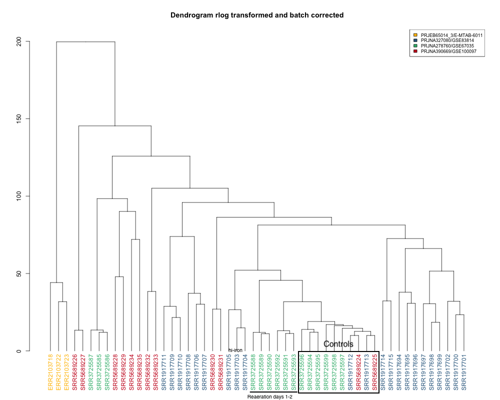

batch correction dendrogram with controls

6. WGCNA

[WGCNA website](https://horvath.genetics.ucla.edu/html/CoexpressionNetwork/Rpackages/WGCNA/)